# Symptom and syndrome network analysis – MATER project

Vincent P. Martin

2024-01-18

```r
rm(list=ls())
```

```r
#initializing environement and loading packages

library(EGAnet)
library(readr)
library(tidyr)
library(vtable)
library(dplyr)
library(qgraph)
library(bootnet)
library(NetworkComparisonTest)
library(ggplot2)
library(forcats)
library(GGally)
library(corrplot)
```

# Global variables

```r
# Global variables
THRESHOLD_UVA = 0.25
N_BOOT_EGA = 1000
CORR_EGA = "spearman"
CORR_qgraph = CORR_EGA
LAMBDA_MIN_RATIO = 0.1
GAMMA = 0.5
GAMMAHL = 0.5
N_BOOTS_CENTRALITY = 1000
N_BOOTS_NCT = 1000
N_BOOTS_CENTRALITY_HL = 1000
N_BOOTS_NCT_high_level = 1000

PAJUST = "BH" # holm, BH, bonferroni
NCORE = 4
set.seed(42)

FORCE_BOOT = FALSE

folder_results="./figures/"
folder_boot_res = "./boot_data/"
```

```r
# loading data and keeping only cancer
data_complete <- read_delim("../../colive_data_recoded.csv")
print(dim(data_complete))
```

```
## [1] 4917  261
```

```r
# keeping only breast cancer
data <- data_complete[data_complete["cancer"] == "yes",]
data <- data[data["ca-loc-1"] == "breast",]
data <- data[data["gender"] == "female",]
```

# Selecting dimensions

```r
list_questionnaires = c(
  'bowPb',
  'H/A',
  'pain',
  'stress',
  'fss_1',  'fss_2',  'fss_3',  'fss_4',  'fss_5',  'fss_6',  'fss_7',  'fss_8',
  'fss_9',
  'who5_1',  'who5_2',  'who5_3',  'who5_4', 'who5_5',
  'vq11_1', 'vq11_2', 'vq11_3', 'vq11_4', 'vq11_5', 'vq11_6', 'vq11_7', 'vq11_8', 'vq11_9', 'vq11_10', 'vq11_11',
  'phq9_1', 'phq9_2', 'phq9_3', 'phq9_4', 'phq9_5','phq9_6','phq9_7','phq9_8',
  'phq9_9'
)

# covariates data
covariates = c('age','BMI','Edu.L','A.days','A.glass', 'A.heavy','Cig.')

# stratification variables
stratif = c('ageCancer','durationCancer','cancerTreatment','diagDepression', 'cancer_tt_surgery','cancer_tt_chemo','cancer_tt_radio','cancer_tt_immuno', 'cancer_tt_hormono','cancer_tt_other')
```

```r
data_questionnaires <- data[, which(names(data) %in% list_questionnaires)]

sumtable(data_questionnaires)
```

Summary Statistics

| Variable | N | Mean | Std. Dev. | Min | Pctl. 25 | Pctl. 75 | Max |
| --- | --- | --- | --- | --- | --- | --- | --- |
| stress | 347 | 2.7 | 1.3 | 1 | 2 | 4 | 5 |
| fss_1 | 347 | 4.9 | 1.6 | 1 | 4 | 6 | 7 |
| fss_2 | 347 | 3.4 | 1.8 | 1 | 2 | 5 | 7 |
| fss_3 | 347 | 4.7 | 1.8 | 1 | 3 | 6 | 7 |
| fss_4 | 347 | 4.5 | 1.7 | 1 | 3 | 6 | 7 |
| fss_5 | 347 | 4.4 | 1.9 | 1 | 3 | 6 | 7 |
| fss_6 | 347 | 4.5 | 1.9 | 1 | 3 | 6 | 7 |
| fss_7 | 347 | 4.3 | 1.8 | 1 | 3 | 5.5 | 7 |
| fss_8 | 347 | 4.8 | 1.9 | 1 | 4 | 7 | 7 |
| fss_9 | 347 | 4.4 | 1.9 | 1 | 3 | 6 | 7 |
| who5_1 | 347 | 3.2 | 1.2 | 1 | 2 | 4 | 6 |
| who5_2 | 347 | 3.4 | 1.3 | 1 | 2 | 4 | 6 |
| who5_3 | 347 | 4.1 | 1.4 | 1 | 3 | 5 | 6 |
| who5_4 | 347 | 4.3 | 1.5 | 1 | 3 | 6 | 6 |
| who5_5 | 347 | 3.3 | 1.4 | 1 | 2 | 5 | 6 |
| phq9_1 | 347 | 2 | 0.98 | 1 | 1 | 3 | 4 |
| phq9_2 | 347 | 1.9 | 0.86 | 1 | 1 | 2 | 4 |
| phq9_3 | 347 | 2.6 | 1.1 | 1 | 2 | 4 | 4 |
| phq9_4 | 347 | 2.7 | 1 | 1 | 2 | 4 | 4 |
| phq9_5 | 347 | 2 | 1.1 | 1 | 1 | 3 | 4 |
| phq9_6 | 347 | 1.8 | 1 | 1 | 1 | 2 | 4 |
| phq9_7 | 347 | 1.9 | 0.96 | 1 | 1 | 2 | 4 |
| phq9_8 | 347 | 1.3 | 0.72 | 1 | 1 | 1 | 4 |
| phq9_9 | 347 | 1.2 | 0.47 | 1 | 1 | 1 | 4 |
| vq11_1 | 347 | 1.8 | 0.93 | 1 | 1 | 2 | 5 |
| vq11_2 | 347 | 1.4 | 0.64 | 1 | 1 | 2 | 5 |
| vq11_3 | 347 | 1.8 | 1 | 1 | 1 | 2 | 5 |
| vq11_4 | 347 | 1.3 | 0.66 | 1 | 1 | 1 | 5 |
| vq11_5 | 347 | 1.8 | 0.95 | 1 | 1 | 2 | 5 |
| vq11_6 | 347 | 2 | 1.1 | 1 | 1 | 3 | 5 |
| vq11_7 | 347 | 2.4 | 1.2 | 1 | 1 | 3 | 5 |
| vq11_8 | 347 | 2.7 | 1.3 | 1 | 2 | 4 | 5 |
| vq11_9 | 347 | 1.1 | 0.53 | 1 | 1 | 1 | 5 |
| vq11_10 | 347 | 2 | 1.1 | 1 | 1 | 3 | 5 |
| vq11_11 | 347 | 1.1 | 0.43 | 1 | 1 | 1 | 4 |
| pain | 347 | 2.4 | 2.3 | 0 | 0 | 4 | 10 |
| bowPb | 347 | 1.4 | 0.49 | 1 | 1 | 2 | 2 |
| H/A | 347 | 1.3 | 0.45 | 1 | 1 | 2 | 2 |

# 1) Unique Variable Analysis

Ressource: r-ega.net/articles/ega.html

### UVA

```r
colive_uva <- UVA(
  data = data_questionnaires,
  cut.off = THRESHOLD_UVA,
  verbose = TRUE,
  #key = items# Optional: provide item descriptions
)

colive_uva # to display the result
```

```
## Variable pairs with wTO > 0.30 (large-to-very large redundancy)
##
##  node_i  node_j   wto
##  vq11_1  vq11_4 0.346
##  who5_5  phq9_1 0.337
##  vq11_9 vq11_11 0.303
##
## ----
##
## Variable pairs with wTO > 0.25 (moderate-to-large redundancy)
##
##  node_i node_j   wto
##  who5_1 who5_2 0.255
##
## ----
##
## Variable pairs with wTO > 0.20 (small-to-moderate redundancy)
##
##  node_i  node_j   wto
##  phq9_2 vq11_10 0.250
##   fss_7   fss_9 0.237
##   fss_3   fss_5 0.213
##  vq11_1  vq11_2 0.208
##  vq11_7  vq11_8 0.202
```

The Weighted Topological Overlap (WTO) measures the degree of association of two variables. The higher the WTO, the higher the chances that two nodes in the network will highly correlate with each other and fewly with the rest of the network.

With a threshold of wto>0.25:

```r
colive_uva$keep_remove
```

```
## $keep
## [1] "who5_1" "who5_5" "vq11_4" "vq11_9"
##
## $remove
## [1] "who5_2"  "phq9_1"  "vq11_1"  "vq11_11"
```

```r
dataset_symptoms <- colive_uva$reduced_data
```

# 2) Symptom network Analysis

```r
item_names <- c(
  'bowPb'="Bowel movements problem",
  'H/A'="Regular headache or migraine",
  'pain'="Instantaneous pain",
  'stress'="Instantaneous stress",
  'fss_1'="My motivation is lower when I am fatigued",
  'fss_2'="Exercise brings on my fatigue",
  'fss_3'="I am easily fatigued",
  'fss_4'="Fatigue interferes with my physical functioning",
  'fss_5'="Fatigue causes frequent problems for me",
  'fss_6'="My fatigue prevents sustained physical functioning",
  'fss_7'="F. inteferes with carrying out duties and responsabilities",
  'fss_8'="F. is among my three most disabling symptoms",
  'fss_9'="F. interferes with my work, family, or social life",
  'who5_1'="I have felt cheerful and in good spirits",
  'who5_2'="I have felt calm and relaxed",
  'who5_3'="I have felt active and vigorous",
  'who5_4'="I woke up feeling fresh and rested",
  'who5_5'="My daily life has been filled with things that interest me",
  'vq11_1'="I suffer from my shortness of breath",
  'vq11_2'="I worry about my respiratory state",
  'vq11_3'="I feel misunderstood by those around me",
  'vq11_4'="My respiratory state prevents me from moving as I would like",
  'vq11_5'="I'm sleepy during the day",
  'vq11_6'="I feel incapable of carrying out my projects",
  'vq11_7'="I get tired quickly in the activities of daily living",
  'vq11_8'="Physically I'm dissatisfied with what I can do",
  'vq11_9'="My respiratory disease is disrupting my social life",
  'vq11_10'="I feel sad",
  'vq11_11'="My respiratory state limits my emotional life",
  'phq9_1'="Little interest or pleasure in doing things?",
  'phq9_2'="Feeling down, depressed, or hopeless",
  'phq9_3'="Trouble falling or staying asleep, or sleeping too much?",
  'phq9_4'="Feeling tired or having little energy?",
  'phq9_5'="Poor appetite or overeating?",
  'phq9_6'="Feeling bad about yourself [...]?",
  'phq9_7'="Trouble concentrating on things [...] ?",
  'phq9_8'="Moving or speaking slowly [..]? Or fidgety or restless [...] ?",
  'phq9_9'=" Thoughts that you would be better off dead [...]?",
  'age'="Age",
  'BMI'="Body Mass Index",
  'Edu.L'="Education Level",
  'A.days'="Number of days with alcohol consumption",
  'A.glass'="Number of alcoholic drinks (typical day)?",
  'A.heavy'="Number of days heavy drinking",
  'Cig.'= "Number of cigarest per day"
)
```

```r
symptom_network <- estimateNetwork(dataset_symptoms,
                           default = "EBICglasso",
                           tuning = GAMMA,
                           lambda.min.ratio = LAMBDA_MIN_RATIO, # similar to EGA
                           corMethod = CORR_qgraph #spearman
                           )
```

## Function to plot symptom network

```r
plot_symptom_network <-
  function(symptom_network,
           layout,
           threshold,
           items_name,
           groups_name = c(),
           edge_labels = FALSE,
           level = "symptom",
           LAYOUTSCALE=c(1.2, 1),
           LAYOUTOFFSET=c(0,0)){
    if (length(groups_name) ==0 && level == "symptom") {
      groups = as.list(rep(0, length(items_name)))
      legend_mode = "names"
    }else if (level == "symptom"){
      groups=unname(groups_name[colnames(symptom_network$data)])
      legend_mode = "style1"
    }
    else {
      groups=unname(groups_name[colnames(symptom_network$data)])
      legend_mode = "groups"
    }
    plot(
      symptom_network,
      layout = layout,
      groups= groups,
      color = color_palette_EGA("polychrome",wc=unique(groups)),
      #"spring",
      sampleSize = nrow(symptom_network$data),
      # sample size, when graph="glasso" or minimum="sig"
      label.cex = 0.8,
      # scalar on label size
      label.color = 'black',
      # string on label colors
      label.prop = 0.9,
      # proportion of the width of the node that the label scales
      layoutOffset = LAYOUTOFFSET,
      #offset of the graph with the legend

      # Edges (pp. 33-34)
      negDashed = F,
      # should negative edges be dashed?

      threshold = threshold,
      #threshold on edges
      legend = T,#should we plot the legend ?
      legend.mode = legend_mode,
      legend.cex = 0.7,
      layoutScale = LAYOUTSCALE,
      GLratio = 1.5,

      vsize = 4,
      vsize2 = 4,

      edge.labels = edge_labels,
      edge.label.margin = 0.0,
      edge.label.bg = T,
      edge.label.cex = 0.5,

      nodeNames = unname(items_name[colnames(symptom_network$data)]),

    )
  }
```

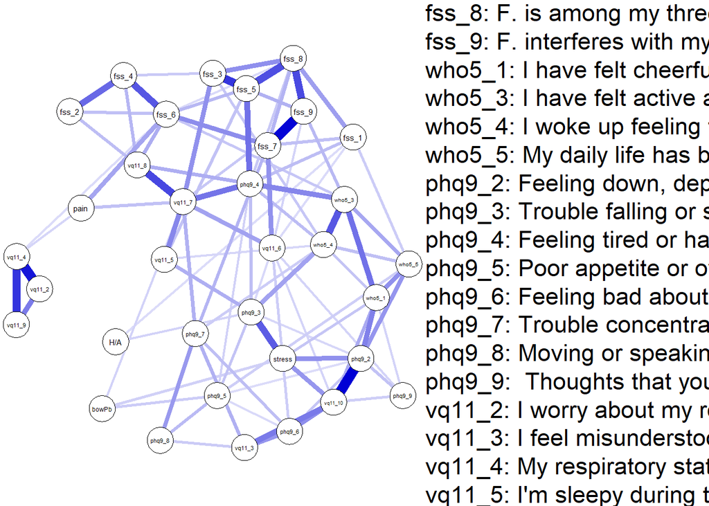

```r
layout = averageLayout(symptom_network,
              symptom_network,
              layout = "spring") # in order to have the same layout for all the symptom networks

# plot it
plot_symptom_network(symptom_network,layout,0.05,item_names)
```

```r
#and save it as pdf
pdf(file = paste(folder_results,"symptom_network_0.05.pdf",sep=""),
    width = 20,
    height = 15)
plot_symptom_network(symptom_network,layout,0.05,item_names)
dev.off()
```

```r
pdf(file = paste(folder_results,"symptom_network_0.10.pdf",sep=""),
    width = 20,
    height = 15)
plot_symptom_network(symptom_network,layout,0.10,item_names)
dev.off()
```

## With covariates

```r
symptom_network_covariates <- estimateNetwork(cbind.data.frame(dataset_symptoms,data[,covariates]),
                           default = "EBICglasso",
                           tuning = GAMMA,
                           lambda.min.ratio = LAMBDA_MIN_RATIO, # similar to EGA
                           corMethod = CORR_qgraph #spearman
                           )
```

```
## Estimating Network. Using package::function:
##   - qgraph::EBICglasso for EBIC model selection
##     - using glasso::glasso
```

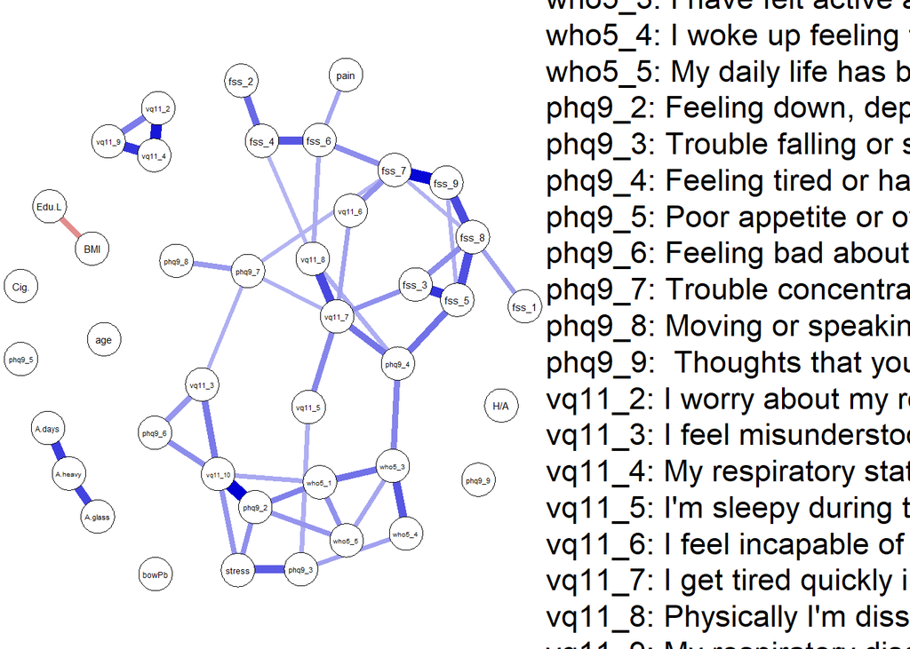

```r
plot_symptom_network(symptom_network_covariates,"spring",0.10,item_names)
```

```r
pdf(file = paste(folder_results,"symptom_network_covariates_0.10.pdf",sep=""),
    width = 20,
    height = 15)
plot_symptom_network(symptom_network_covariates,"spring",0.10,item_names)
dev.off()
```

**Interpretation**

With a threshold of 0.1, Age, BMI, Edu. level, Alcohol consumption and cigaret consumption do not interact with the other dimensions of the network. The results about relationship between the symptoms are thus supposed as independant from the effect of these covariates.

## Stability of the edges

```r
file = paste(folder_boot_res,"bootnet_nonpar.Rdata",sep = "")
if(file.exists(file)&& FORCE_BOOT==FALSE){
  load(file)
}else{
bootnet_nonpar <- bootnet(symptom_network,
                          nBoots = N_BOOTS_CENTRALITY, # number of boot samples
                          corMethod = CORR_qgraph,
                         nCores = NCORE)
save(bootnet_nonpar, file = file)

}
```

```r
pdf(file = paste(folder_results,"edges_stability_low_level.pdf"),
    width = 8,
    height = 5)
plot(bootnet_nonpar,
     labels = FALSE,
     order = "sample")
dev.off()
```

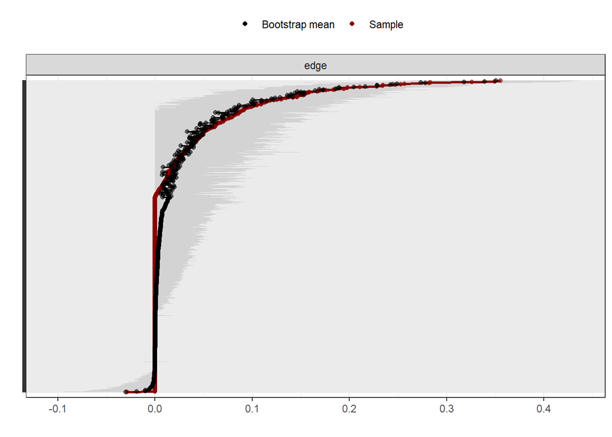

```r
plot(bootnet_nonpar,
     labels = FALSE,
     order = "sample")
```

**Interpretation**

Non parametric bootstrap in order to measure stability of the edges. Each line corresponds to an edges, ordered by value.

## Centrality

### Metrics

```r
pdf(file = paste(folder_results,"centrality_by_strength.pdf"),
    width = 5,
    height = 8)
centralityPlot(symptom_network, include = c("Strength", "Closeness", "Betweenness"), orderBy = "Strength")
dev.off()
```

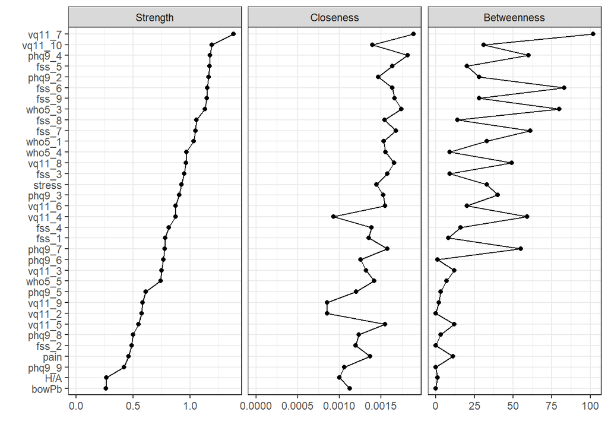

```r
centralityPlot(symptom_network, include = c("Strength", "Closeness", "Betweenness"), orderBy = "Strength")
```

**how to read it ?**

- Definition of the metrics: https://reisrgabriel.com/blog/2021-10-08-centrality/
  - centrality = sum of absolute edges’ weights
  - betweenness = how many time the node is the shortest way between two other nodes
  - closeness = 1/ (sum (1/absolute weights))

  Interpretation: https://www.apa.org/pubs/journals/features/abn-abn0000446.pdf

**Interpretation**

VQ11-7, VQ11-10 and PHQ9-4 are the three most central symptoms in the whole network.

### Stability of the centrality metrics

```r
file = paste(folder_boot_res,"bootnet_case_dropping_all.Rdata",sep = "")
if(file.exists(file)&& FORCE_BOOT==FALSE){
  load(file)
}else{
bootnet_case_dropping_all <- bootnet(symptom_network,
                                 nBoots = N_BOOTS_CENTRALITY,
                                 type = "case",
                                 nCores = NCORE,
                                 tuning = GAMMA,
                                 lambda.min.ratio = LAMBDA_MIN_RATIO, # similar to EGA
                                 corMethod = CORR_qgraph,
                                 statistics = c('strength',
                                                'closeness',
                                                'betweenness'))
save(bootnet_case_dropping_all,file=file)
}
```

```r
pdf(file = paste(folder_results,"stability_centrality_metrics.pdf"),
    width = 6,
    height = 4)
plot(bootnet_case_dropping_all, 'all')
dev.off()
```

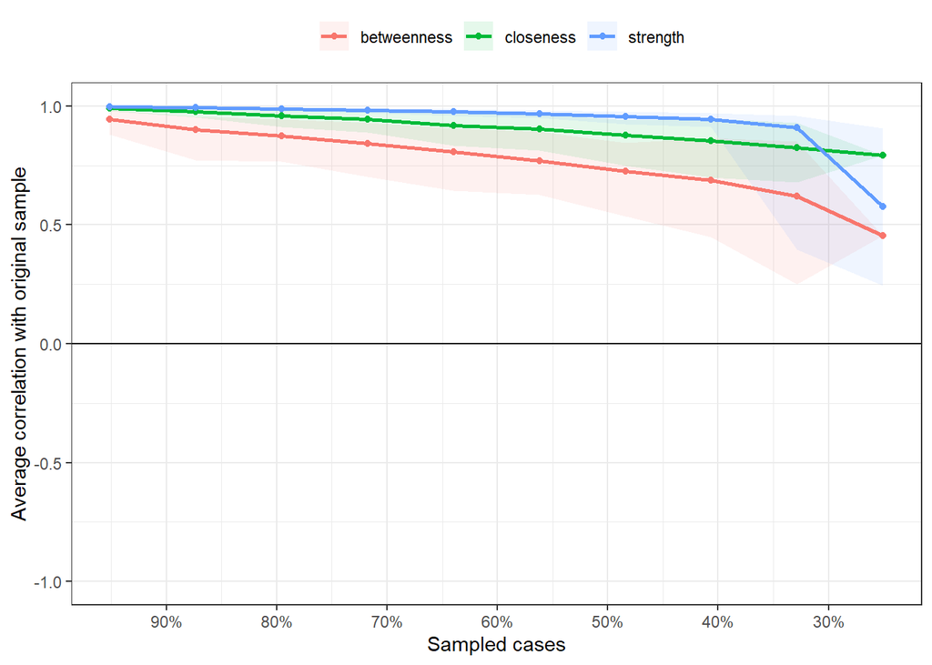

```r
plot(bootnet_case_dropping_all, 'all')
```

**Interpretation**

```r
corStability(bootnet_case_dropping_all)
```

```
## === Correlation Stability Analysis ===
##
## Sampling levels tested:
##    nPerson Drop%   n
## 1       87  74.9  91
## 2      114  67.1 103
## 3      141  59.4 101
## 4      168  51.6 109
## 5      195  43.8 102
## 6      222  36.0 106
## 7      249  28.2  97
## 8      276  20.5 107
## 9      303  12.7  91
## 10     330   4.9  93
##
## Maximum drop proportions to retain correlation of 0.7 in at least 95% of the samples:
##
## betweenness: 0.282
##   - For more accuracy, run bootnet(..., caseMin = 0.205, caseMax = 0.36)
##
## closeness: 0.594
##   - For more accuracy, run bootnet(..., caseMin = 0.516, caseMax = 0.671)
##
## strength: 0.594
##   - For more accuracy, run bootnet(..., caseMin = 0.516, caseMax = 0.671)
##
## Accuracy can also be increased by increasing both 'nBoots' and 'caseN'.
```

**Interpretation**

Epskamp et al. (2018) suggest that “the CS-coefficient should not be below 0.25, and preferably above 0.5.”

Here, we can interpret without risks the strength and the closeness, but we should be more cautious with betweeness.

# 3) EGA: From symptoms to syndromes

## Low level clustering

```r
colive_ega <- EGA(data = dataset_symptoms,
                         model = c("glasso"),
                         algorithm = "Louvain", #forcing Louvain because it is the only validated for hierarchical network
                         lamdba.min.ratio = LAMBDA_MIN_RATIO,
                         gamma = GAMMA,
                         corr= CORR_EGA,
                         order = "Lower" # do not forget this parameter indicating that it is the lower level in hierarchy (default = higher)
                         )
```

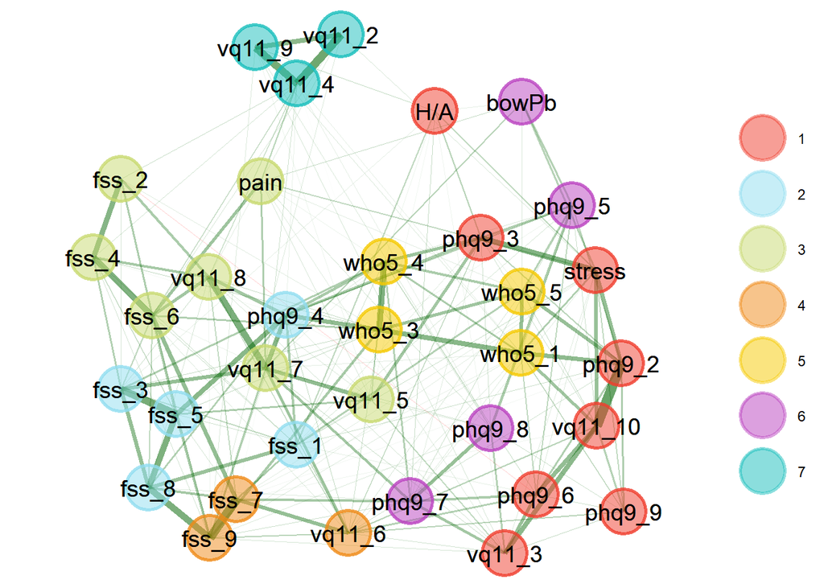

```r
summary(colive_ega)
```

```
## Model: GLASSO (EBIC with gamma = 0.5)
## Correlations: spearman
## Lambda: 0.0818233276230608 (n = 100, ratio = 0.1)
##
## Number of nodes: 34
## Number of edges: 211
## Edge density: 0.376
##
## Non-zero edge weights:
##      M    SD    Min   Max
##  0.067 0.070 -0.029 0.356
##
## ----
##
## Consensus Method: Most Common (1000 iterations)
## Algorithm: Louvain
## Order: Lower
##
## Number of communities:  7
##
##  stress   fss_1   fss_2   fss_3   fss_4   fss_5   fss_6   fss_7   fss_8   fss_9
##       1       2       3       2       3       2       3       4       2       4
##  who5_1  who5_3  who5_4  who5_5  phq9_2  phq9_3  phq9_4  phq9_5  phq9_6  phq9_7
##       5       5       5       5       1       1       2       6       1       6
##  phq9_8  phq9_9  vq11_2  vq11_3  vq11_4  vq11_5  vq11_6  vq11_7  vq11_8  vq11_9
##       6       1       7       1       7       3       4       3       3       7
## vq11_10    pain   bowPb     H/A
##       1       3       6       1
##
## ----
##
## Unidimensional Method: Louvain
## Unidimensional: No
##
## ----
##
## TEFI: -10.528
```

**Interpretation**

Using a Louvain algorithm to minimize the TEFI, we obtained 7 clusters of symptoms (i.e. 7 syndromes).

The next step is to name these syndromes, based on the replication of each item into the cluster and the loadings

## Stability of low level graph

```r
file = paste(folder_boot_res,"colive_boot.Rdata",sep = "")
if(file.exists(file)&& FORCE_BOOT==FALSE){
  load(file)
}else{
colive_boot <- bootEGA(
  data = dataset_symptoms,
  model = "glasso",
  lamdba.min.ratio = LAMBDA_MIN_RATIO,
  gamma = GAMMA,
  corr= CORR_EGA,
  algorithm = "Louvain",
  seed = 42, # set seed for reproducibility
  iter = N_BOOT_EGA,
  n_core = NCORE,
  order = "Lower",
  plot = FALSE
  )
save(colive_boot,file = file)
}
```

```r
stability <- dimensionStability(colive_boot)
```

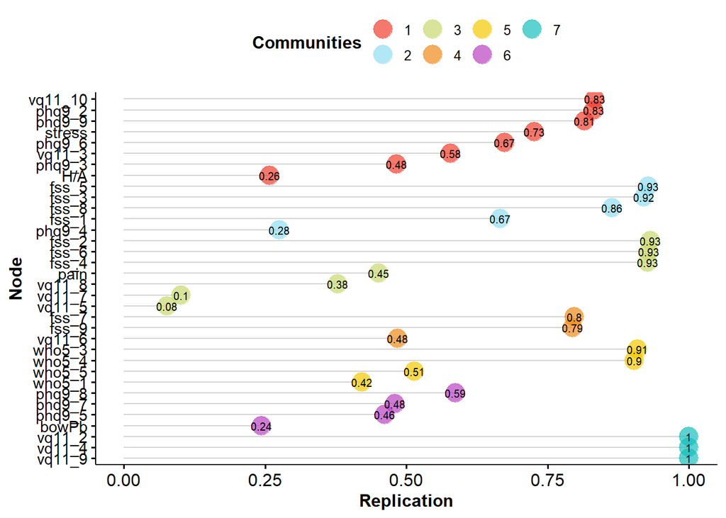

```r
pdf(file = paste(folder_results,"stability_EGA_lowlevel.pdf"),
    width = 5,
    height = 8)
dimensionStability(colive_boot)
```

```
## EGA Type: EGA
## Bootstrap Samples: 1000 (Parametric)
##
## Proportion Replicated in Dimensions:
##
##  stress   fss_1   fss_2   fss_3   fss_4   fss_5   fss_6   fss_7   fss_8   fss_9
##   0.726   0.666   0.932   0.920   0.927   0.928   0.929   0.797   0.864   0.794
##  who5_1  who5_3  who5_4  who5_5  phq9_2  phq9_3  phq9_4  phq9_5  phq9_6  phq9_7
##   0.421   0.909   0.903   0.514   0.832   0.483   0.275   0.462   0.674   0.480
##  phq9_8  phq9_9  vq11_2  vq11_3  vq11_4  vq11_5  vq11_6  vq11_7  vq11_8  vq11_9
##   0.587   0.815   1.000   0.578   1.000   0.076   0.485   0.101   0.378   1.000
## vq11_10    pain   bowPb     H/A
##   0.833   0.451   0.244   0.258
##
## ----
##
## Structural Consistency:
##
##     1     2     3     4     5     6     7
## 0.059 0.223 0.010 0.481 0.398 0.079 1.000
```

```r
dev.off()
```

**Interpretation**

Each number corresponds to the replication rate of the item to the assigned cluster. When interpretating the clusters of symptoms (i.e. the syndromes), we have taken into account these replication to weight the implication of the items in the clusters.

## Plotting symptom network with colors !

### Name of the dimensions

```r
list_dimensions = c("1. Depressive syndrome",
                    "2. Fatigue Disability",
                    "3. Fatigue-related physical impairment",
                    "4. Fatigue Handicap",
                    "5. Well-being",
                    "6. Cognition and psychosomatic",
                    "7. Respiratory state handicap")
dico_groups <- c()
for (i in 0:length(colive_ega$dim.variables$items)){
  dico_groups[colive_ega$dim.variables$items[i]] = list_dimensions[strtoi(colive_ega$dim$dimension[i])]
}
```

### Plotting symptom network with clusters

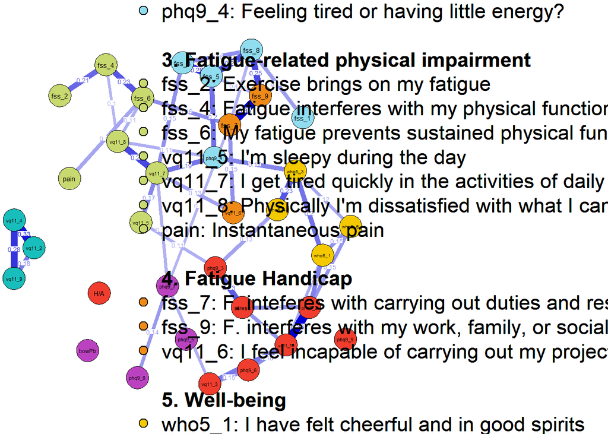

```r
# plot it
plot_symptom_network(symptom_network,layout,0.10,item_names, dico_groups,edge_label = TRUE)
```

```r
#and save it as pdf
pdf(file = paste(folder_results,"symptom_network_clusters_0.05.pdf",sep=""),
    width = 28,
    height = 15)
plot_symptom_network(symptom_network,layout,0.05,item_names, dico_groups)
dev.off()
```

```r
pdf(file = paste(folder_results,"symptom_network_clusters_0.10.pdf",sep=""),
    width = 28,
    height = 15)
plot_symptom_network(symptom_network,layout,0.10,item_names, dico_groups,edge_label = TRUE)
dev.off()
```

## Hierarchical estimation

```r
colive_ega_hier_glasso <- hierEGA(
  data = dataset_symptoms,
  scores = "network", #factor or network
  model = "glasso",
  corr=CORR_EGA,
  lower.algorithm="Louvain",
  lamdba.min.ratio = LAMBDA_MIN_RATIO,
  gamma = GAMMA,
  plot.EGA = FALSE, # No plot for CRAN checks,
  seed = 42# or sepatate
  )
summary(colive_ega_hier_glasso)
```

```
## Lower Order
##
## Model: GLASSO (EBIC with gamma = 0.5)
## Correlations: spearman
## Lambda: 0.0818233276230608 (n = 100, ratio = 0.1)
##
## Number of nodes: 34
## Number of edges: 211
## Edge density: 0.376
##
## Non-zero edge weights:
##      M    SD    Min   Max
##  0.067 0.070 -0.029 0.356
##
## ----
##
## Consensus Method: Most Common (1000 iterations)
## Algorithm: Louvain
## Order: Lower
##
## Number of communities:  7
##
##  stress   fss_1   fss_2   fss_3   fss_4   fss_5   fss_6   fss_7   fss_8   fss_9
##       1       2       3       2       3       2       3       4       2       4
##  who5_1  who5_3  who5_4  who5_5  phq9_2  phq9_3  phq9_4  phq9_5  phq9_6  phq9_7
##       5       5       5       5       1       1       2       6       1       6
##  phq9_8  phq9_9  vq11_2  vq11_3  vq11_4  vq11_5  vq11_6  vq11_7  vq11_8  vq11_9
##       6       1       7       1       7       3       4       3       3       7
## vq11_10    pain   bowPb     H/A
##       1       3       6       1
##
## ----
##
## Unidimensional Method: Louvain
## Unidimensional: No
##
## ----
##
## TEFI: -10.528
##
```

[output cut: 22 more lines]

```
## 1 2 3 4 5 6 7
## 1 1 1 1 1 1 1
##
## ----
##
## Unidimensional Method: Louvain
## Unidimensional: Yes
##
## ----
##
## TEFI: -46.541
##
## ----
##
## Generalized TEFI: -57.069
```

```r
pdf(file = "./figures_baseline/hierEGA_multilevel.pdf",
    width = 8,
    height = 6)
plot(colive_ega_hier_glasso, plot.type = "multilevel")
dev.off()
```

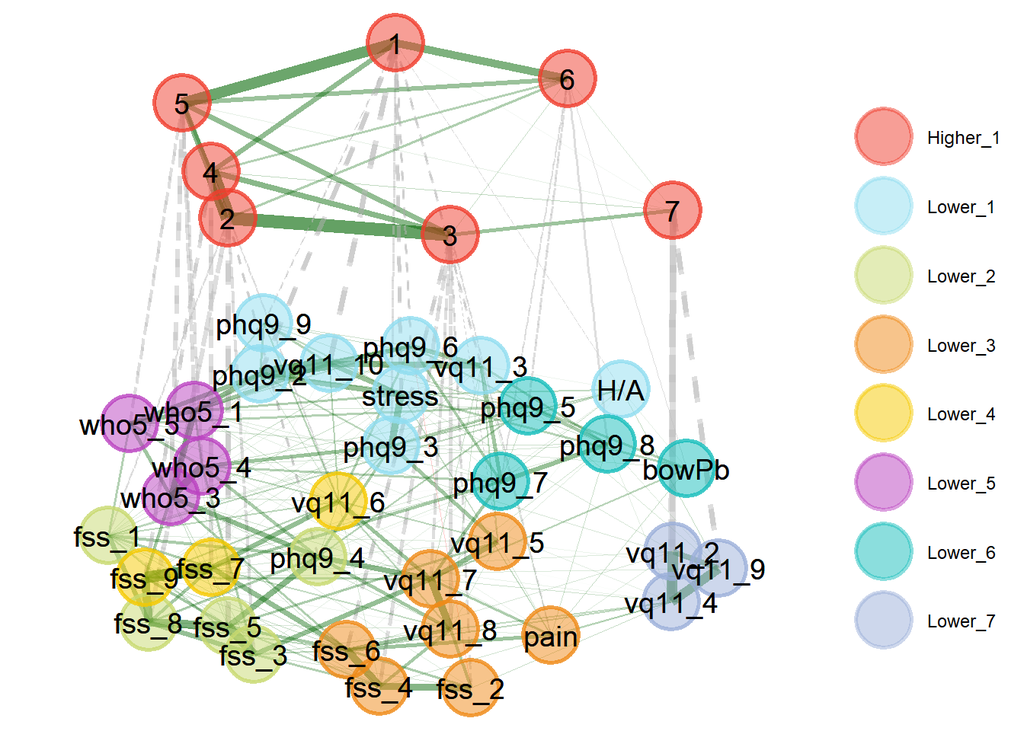

```r
plot(colive_ega_hier_glasso, plot.type = "multilevel")
```

**Interpretation**

Now that we have computed syndromes from symptoms, we can run a network analysis on them !

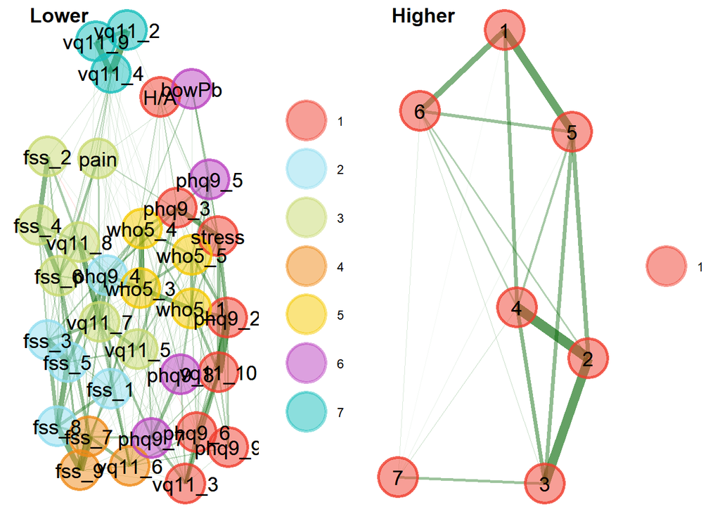

```r
plot(colive_ega_hier_glasso, plot.type = "separate", color.match = TRUE)
```

```r
# saving the loadings in a file
write.table(colive_ega_hier_glasso$parameters$lower_loadings, file = paste(folder_results,"loadings_EGA.txt"), sep = ",", quote = FALSE, row.names = T)
```

## (Nice) plot of loadings

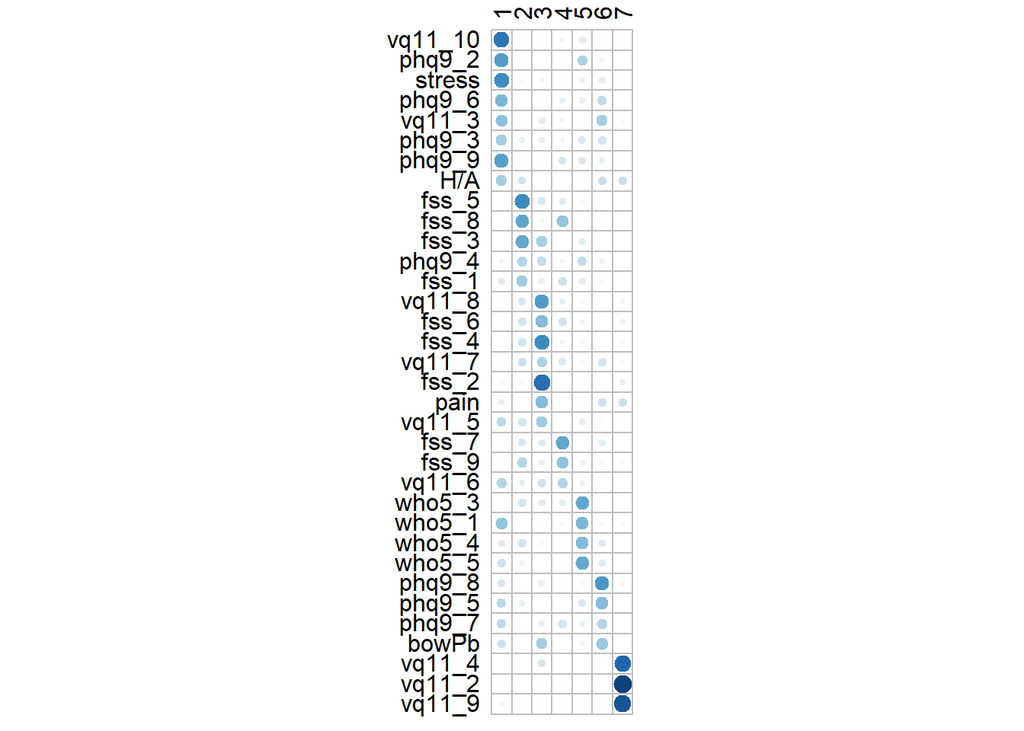

```r
library(RColorBrewer)
coul <- colorRampPalette(brewer.pal(9, "Blues"))(25)

loadings = abs(colive_ega_hier_glasso$parameters$lower_loadings)
loadings <- diag(1/rowSums(loadings)) %*% loadings

loadings <- t(loadings)
colnames(loadings) <-  rownames(colive_ega_hier_glasso$parameters$lower_loadings)

corrplot(t(loadings),
         tl.col = "black", tl.srt = 90,
         cl.pos = 'n'
         )
```

```r
pdf(file = paste(folder_results,"hier_loadings.pdf"),
    width = 2.5,
    height = 8)
corrplot(t(loadings),
         tl.col = "black", tl.srt = 90,
         cl.pos = 'n'
         )
dev.off()
```

# 4) Syndrome network

### Computing the syndrome dataset (scores to the Louvain clustering algorithm)

```r
dataset_syndrome <- colive_ega_hier_glasso$parameters$lower_scores

colnames(dataset_syndrome)[1] = "1"
colnames(dataset_syndrome)[2] = "2"
colnames(dataset_syndrome)[3] = "3"
colnames(dataset_syndrome)[4] = "4"
colnames(dataset_syndrome)[5] = "5"
colnames(dataset_syndrome)[6] = "6"
colnames(dataset_syndrome)[7] = "7"

dataset_all_syndrome <- cbind.data.frame(dataset_syndrome,data[which(names(data) %in% stratif)])
```

```r
dico_syndrome = c()
for (i in 1:length(list_dimensions)){
  dico_syndrome[as.character(i)] = list_dimensions[i]
}

for (cov in covariates){
  dico_syndrome[cov] = "covariate"
}
```

### Syndrom network

```r
syndrome_network <- estimateNetwork(dataset_syndrome,
                            default = "EBICglasso",
                            tuning = GAMMAHL,
                            lambda.min.ratio = LAMBDA_MIN_RATIO, # similar to EGA
                            corMethod = CORR_qgraph #spearman
                           )
```

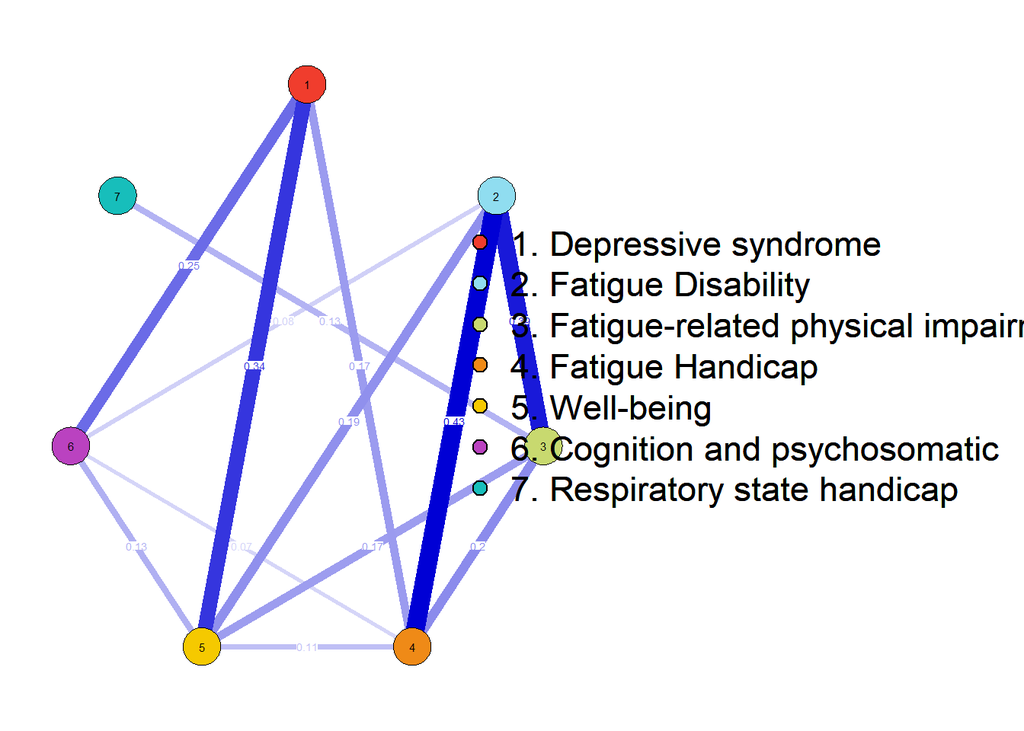

```r
layout = averageLayout(syndrome_network,
              syndrome_network,
              layout = "circular") # in order to have the same layout for all the symptom networks

plot_symptom_network(syndrome_network,layout,0.05,dico_syndrome, dico_syndrome,edge_labels = TRUE, level = "syndrome",LAYOUTSCALE=c(1,1))
```

```r
#and save it as pdf
pdf(file = paste(folder_results,"syndrome_network_0.05.pdf",sep=""),
    width = 10,
    height = 6)
plot_symptom_network(syndrome_network,layout,0.05,dico_syndrome, dico_syndrome,edge_labels = TRUE, level = "syndrome",LAYOUTSCALE=c(1,1), LAYOUTOFFSET = c(-0.1,0))
dev.off()
```

```r
pdf(file = paste(folder_results,"syndrome_network_0.10.pdf",sep=""),
    width = 10,
    height = 6)
plot_symptom_network(syndrome_network,layout,0.10,dico_syndrome, dico_syndrome,edge_labels = TRUE, level = "syndrome",LAYOUTSCALE=c(1,1), LAYOUTOFFSET = c(-0.1,0))
dev.off()
```

### With covariates

```r
syndrome_network_covariates <- estimateNetwork(cbind.data.frame(dataset_syndrome,data[,covariates]),
                           default = "EBICglasso",
                           tuning = GAMMA,
                           lambda.min.ratio = LAMBDA_MIN_RATIO, # similar to EGA
                           corMethod = CORR_qgraph #spearman
                           )
```

```
## Estimating Network. Using package::function:
##   - qgraph::EBICglasso for EBIC model selection
##     - using glasso::glasso
```

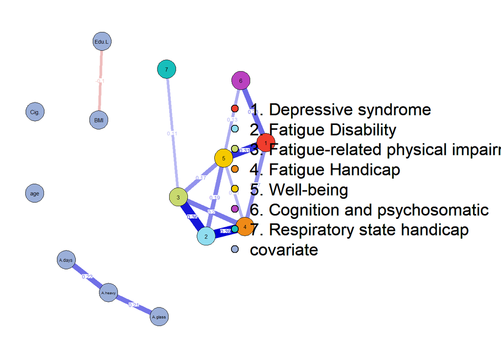

```r
plot(
      syndrome_network_covariates,
      layout = "spring",
      color = color_palette_EGA("polychrome",wc=unname(dico_syndrome[colnames(syndrome_network_covariates$data)])),
      groups = unname(dico_syndrome[colnames(syndrome_network_covariates$data)]),
      sampleSize = nrow(syndrome_network_covariates$data),
      # sample size, when graph="glasso" or minimum="sig"
      label.cex = 0.8,
      # scalar on label size
      label.color = 'black',
      # string on label colors
      label.prop = 0.9,
      # proportion of the width of the node that the label scales
      layoutOffset = c(0,0),
      #offset of the graph with the legend

      threshold = 0.10,
      #threshold on edges
      legend = T,#should we plot the legend ?
      legend.mode = "groups",
      legend.cex = 0.7,
      layoutScale = c(1,1),
      GLratio = 1.5,

      vsize = 4,
      vsize2 = 4,

      edge.labels = T,
      edge.label.margin = 0.0,
      edge.label.bg = T,
      edge.label.cex = 0.5,

)
```

```r
pdf(file = paste(folder_results,"syndrome_network_covariates_0.10.pdf",sep=""),
    width = 20,
    height = 15)
plot_symptom_network(symptom_network_covariates,"spring",0.10,item_names)
dev.off()
```

**Interpretation**

With a threshold of 0.1, Age, BMI, Edu. level, Alcohol consumption and cigaret consumption do not interact with the other dimensions of the network. The results about relationship between the syndromes are thus supposed to be independent from the effect of these covariates.

## Stability of the edges

```r
file = paste(folder_boot_res,"bootnet_nonpar_syndrome.Rdata",sep = "")
if(file.exists(file)&& FORCE_BOOT==FALSE){
  load(file)
}else{
bootnet_nonpar_syndrome <- bootnet(syndrome_network,
                          nBoots = N_BOOTS_CENTRALITY, # number of boot samples
                          corMethod = CORR_qgraph,
                         nCores = NCORE)
save(bootnet_nonpar_syndrome, file = file)

}
```

```r
pdf(file = paste(folder_results,"edges_stability_high_level.pdf"),
    width = 8,
    height = 5)
plot(bootnet_nonpar_syndrome,
     labels = FALSE,
     order = "sample")
dev.off()
```

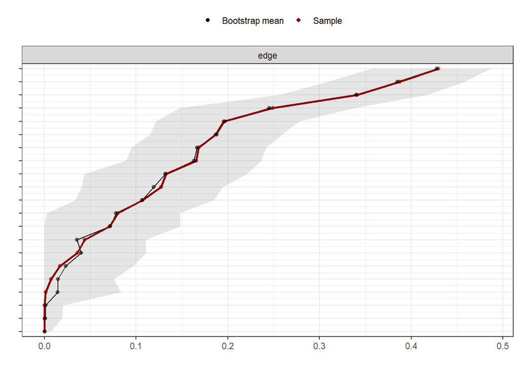

```r
plot(bootnet_nonpar_syndrome,
     labels = FALSE,
     order = "sample")
```

## Syndromes centrality

### Metrics

```r
pdf(file = paste(folder_results,"centrality_by_strength.pdf"),
    width = 5,
    height = 8)
centralityPlot(syndrome_network, include = c("Strength", "Closeness", "Betweenness"), orderBy = "Strength")
dev.off()
```

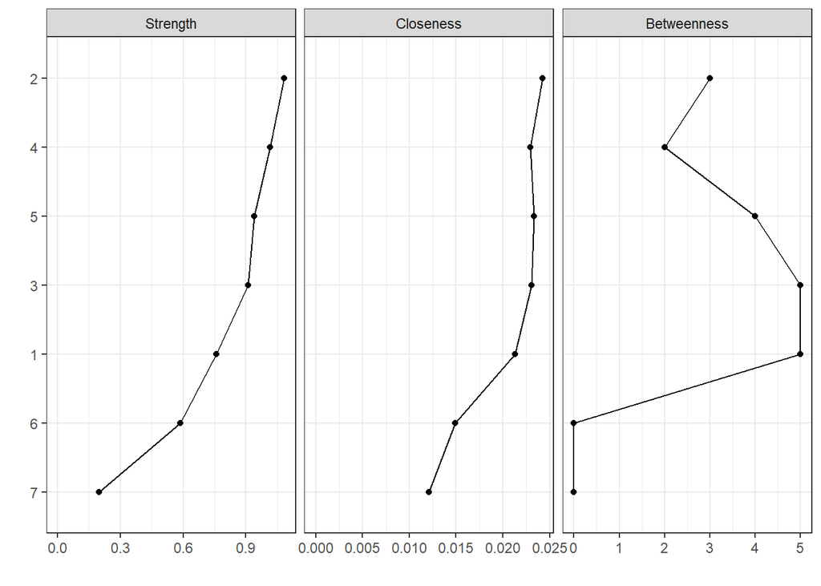

```r
centralityPlot(syndrome_network, include = c("Strength", "Closeness", "Betweenness"), orderBy = "Strength")
```

**how to read it ?**

- Definition of the metrics: https://reisrgabriel.com/blog/2021-10-08-centrality/
  - centrality = sum of absolute edges’ weights
  - betweenness = how many time the node is the shortest way between two other nodes
  - closeness = 1/ (sum (1/absolute weights))

  Interpretation: https://www.apa.org/pubs/journals/features/abn-abn0000446.pdf

**Interpretation**

Fatigue diasability (2), Fatigue handicap (4) and Well-being (5) are the three most central symptoms in the syndrome network.

### Stability of the centrality metrics

```r
file = paste(folder_boot_res,"bootnet_case_dropping_all_syndrome.Rdata",sep = "")
if(file.exists(file)&& FORCE_BOOT==FALSE){
  load(file)
}else{
bootnet_case_dropping_all_syndrome <- bootnet(syndrome_network,
                                 nBoots = N_BOOTS_CENTRALITY,
                                 type = "case",
                                 nCores = NCORE,
                                 tuning = GAMMA,
                                 lambda.min.ratio = LAMBDA_MIN_RATIO, # similar to EGA
                                 corMethod = CORR_qgraph,
                                 statistics = c('strength',
                                                'closeness',
                                                'betweenness'))
save(bootnet_case_dropping_all_syndrome,file=file)
}
```

```r
pdf(file = paste(folder_results,"stability_centrality_metrics_syndrome.pdf"),
    width = 6,
    height = 4)
plot(bootnet_case_dropping_all_syndrome, 'all')
dev.off()
```

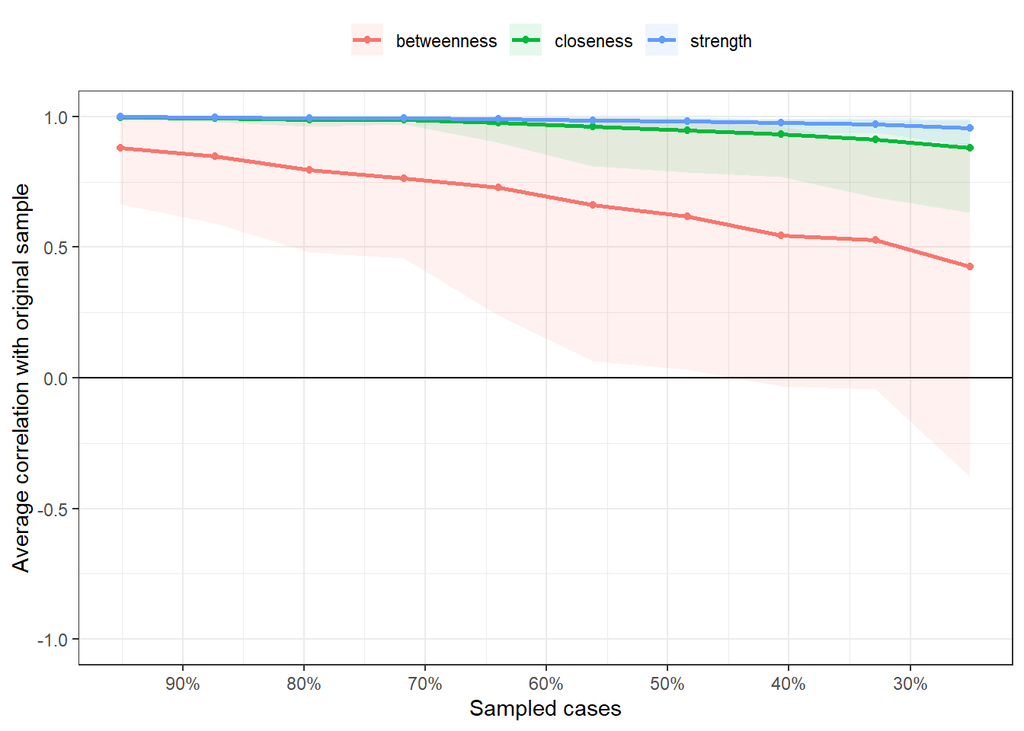

```r
plot(bootnet_case_dropping_all_syndrome, 'all')
```

**Interpretation**

```r
corStability(bootnet_case_dropping_all_syndrome)
```

```
## === Correlation Stability Analysis ===
##
## Sampling levels tested:
##    nPerson Drop%   n
## 1       87  74.9  99
## 2      114  67.1 114
## 3      141  59.4  97
## 4      168  51.6  94
## 5      195  43.8  98
## 6      222  36.0  94
## 7      249  28.2  95
## 8      276  20.5 100
## 9      303  12.7 110
## 10     330   4.9  99
##
## Maximum drop proportions to retain correlation of 0.7 in at least 95% of the samples:
##
## betweenness: 0
##   - For more accuracy, run bootnet(..., caseMin = 0, caseMax = 0.049)
##
## closeness: 0.749 (CS-coefficient is highest level tested)
##   - For more accuracy, run bootnet(..., caseMin = 0.671, caseMax = 1)
##
## strength: 0.749 (CS-coefficient is highest level tested)
##   - For more accuracy, run bootnet(..., caseMin = 0.671, caseMax = 1)
##
## Accuracy can also be increased by increasing both 'nBoots' and 'caseN'.
```

**Interpretation**

Epskamp et al. (2018) suggest that “the CS-coefficient should not be below 0.25, and preferably above 0.5.”

Here, we can interpret without risks the strength and the closeness, but we can not intepret betweeness, which is too unstable.